# R Team Project

Jihyun Kim

2020 7 18

### A반 이수빈 김지현 양지원 이민준

### **1. Crime in North Carolina**

## 노스캐롤라이나 주

- 미국 남부지역의 주로서 100개의 카운티를 가지고 있음.
- 치안율이 좋은 것으로 알려져있음.
- 치안관리를 위해 적극적으로 데이터를 활용하는 주
- 잠재적으로 범죄 위험가능성이 있는 개인에 대한 포괄적인 시선을 필요로 함

-" 어떤 변수를 통해서 위험이 있는 지역과 개인들을 솎아낼 수 있을 것인가 ? "

## 데이터의 정보

Raw Data: Crime in North Carolina: 1981~1987년 의 노스캐롤라이나 주의 범죄 관련 정보

```r
# 변수의 종류
crime<-read.csv("C:\\Users\\LENOVO\\Desktop\\이민준\\3주차\\팀플-01\\R Team Project (2)\\Crime in North Carolina.csv")

names <- colnames(crime)
index <- c("구분","카운티","연도","인당 범죄횟수","체포율","유죄 선고율","징역형 비율","평균징역일 수 ","1인당 경찰수","평방 마일당 사람수(100명단위)","1인당세수입","지역","대도시여부","미성년비율","건설업주급","trns, util, commun주급","전체 판매및 소매업 주급","금융, 보험, 부동산업 주급","서비스업주급","제조업주급","연방직원 주급","공무원주급","지방벙부직원주급","위법행위유형","젊은 남성비율" )

df <- data.frame(names, index)
df
```

**output**

```
##      names                         index
## 1        X                          구분
## 2   county                        카운티
## 3     year                          연도
## 4   crmrte                 인당 범죄횟수
## 5   prbarr                        체포율
## 6  prbconv                   유죄 선고율
## 7  prbpris                   징역형 비율
## 8   avgsen                평균징역일 수
## 9    polpc                  1인당 경찰수
## 10 density 평방 마일당 사람수(100명단위)
## 11   taxpc                   1인당세수입
## 12  region                          지역
## 13    smsa                    대도시여부
## 14  pctmin                    미성년비율
## 15    wcon                    건설업주급
## 16    wtuc        trns, util, commun주급
## 17    wtrd       전체 판매및 소매업 주급
## 18    wfir     금융, 보험, 부동산업 주급
## 19    wser                  서비스업주급
## 20    wmfg                    제조업주급
## 21    wfed                 연방직원 주급
## 22    wsta                    공무원주급
## 23    wloc              지방벙부직원주급
## 24     mix                  위법행위유형
## 25 pctymle                 젊은 남성비율
```

#### 변수들 확인하기

```r
crime<-read.csv("C:\\Users\\LENOVO\\Desktop\\이민준\\3주차\\팀플-01\\R Team Project (2)\\Crime in North Carolina.csv")
head(crime, 3)
```

**output**

```
##   X county year    crmrte   prbarr  prbconv  prbpris avgsen     polpc  density
## 1 1      1   81 0.0398849 0.289696 0.402062 0.472222   5.61 0.0017868 2.307159
## 2 2      1   82 0.0383449 0.338111 0.433005 0.506993   5.59 0.0017666 2.330254
## 3 3      1   83 0.0303048 0.330449 0.525703 0.479705   5.80 0.0018358 2.341801
##      taxpc  region smsa  pctmin     wcon      wtuc     wtrd     wfir     wser
## 1 25.69763 central   no 20.2187 206.4803  333.6209 182.3330 272.4492 215.7335
## 2 24.87425 central   no 20.2187 212.7542  369.2964 189.5414 300.8788 231.5767
## 3 26.45144 central   no 20.2187 219.7802 1394.8030 196.6395 309.9696 240.1568
##     wmfg   wfed   wsta   wloc       mix   pctymle
## 1 229.12 409.37 236.24 231.47 0.0999179 0.0876968
## 2 240.33 419.70 253.88 236.79 0.1030491 0.0863767
## 3 269.70 438.85 250.36 248.58 0.0806787 0.0850909
```

```r
str(crime)
```

**output**

```
## 'data.frame':    630 obs. of  25 variables:
##  $ X      : int  1 2 3 4 5 6 7 8 9 10 ...
##  $ county : int  1 1 1 1 1 1 1 3 3 3 ...
##  $ year   : int  81 82 83 84 85 86 87 81 82 83 ...
##  $ crmrte : num  0.0399 0.0383 0.0303 0.0347 0.0366 ...
##  $ prbarr : num  0.29 0.338 0.33 0.363 0.325 ...
##  $ prbconv: num  0.402 0.433 0.526 0.605 0.579 ...
##  $ prbpris: num  0.472 0.507 0.48 0.52 0.497 ...
##  $ avgsen : num  5.61 5.59 5.8 6.89 6.55 6.9 6.71 8.45 5.71 8.69 ...
##  $ polpc  : num  0.00179 0.00177 0.00184 0.00189 0.00192 ...
##  $ density: num  2.31 2.33 2.34 2.35 2.36 ...
##  $ taxpc  : num  25.7 24.9 26.5 26.8 28.1 ...
##  $ region : chr  "central" "central" "central" "central" ...
##  $ smsa   : chr  "no" "no" "no" "no" ...
##  $ pctmin : num  20.2 20.2 20.2 20.2 20.2 ...
##  $ wcon   : num  206 213 220 223 244 ...
##  $ wtuc   : num  334 369 1395 399 359 ...
##  $ wtrd   : num  182 190 197 201 207 ...
##  $ wfir   : num  272 301 310 350 383 ...
##  $ wser   : num  216 232 240 252 261 ...
##  $ wmfg   : num  229 240 270 282 299 ...
##  $ wfed   : num  409 420 439 459 490 ...
##  $ wsta   : num  236 254 250 262 281 ...
##  $ wloc   : num  231 237 249 264 289 ...
##  $ mix    : num  0.0999 0.103 0.0807 0.0785 0.0932 ...
##  $ pctymle: num  0.0877 0.0864 0.0851 0.0838 0.0823 ...
```

#### **데이터 전처리**(for 회귀분석)

1. 칼럼 제거  
   제외하는 변수: X, county, year, prbarr, prbconv, prbpris, region  
   X, county, region: 분석 주제와 관련된 기준이 아니라고 판단하여 제외  
   prbarr, prbconv, prbpris: 종속변수에 의미없는, 당연한 상관관계가 있다고 판단하여 제외

```r
crime <- crime[,-c(1,2,3,5,6,7,12)]
names(crime)
```

**output**

```
##  [1] "crmrte"  "avgsen"  "polpc"   "density" "taxpc"   "smsa"    "pctmin"
##  [8] "wcon"    "wtuc"    "wtrd"    "wfir"    "wser"    "wmfg"    "wfed"
## [15] "wsta"    "wloc"    "mix"     "pctymle"
```

```r
#제외하는 변수: X, county, year, prbarr, prbconv, prbpris, region
#X, county, region: 분석 주제와 관련된 기준이 아니라고 판단하여 제외
#prbarr, prbconv, prbpris:  : 종속변수에 의미없는, 당연한 상관관계가 있다고 판단하여 제외
```

2. factor 변수 smsa를 numeric으로 변환

```r
crime$smsa <- ifelse(crime$smsa == 'no',0,1)
head(crime)
```

**output**

```
##      crmrte avgsen     polpc  density    taxpc smsa  pctmin     wcon      wtuc
## 1 0.0398849   5.61 0.0017868 2.307159 25.69763    0 20.2187 206.4803  333.6209
## 2 0.0383449   5.59 0.0017666 2.330254 24.87425    0 20.2187 212.7542  369.2964
## 3 0.0303048   5.80 0.0018358 2.341801 26.45144    0 20.2187 219.7802 1394.8030
## 4 0.0347259   6.89 0.0018859 2.346420 26.84235    0 20.2187 223.4238  398.8604
## 5 0.0365730   6.55 0.0019244 2.364896 28.14034    0 20.2187 243.7562  358.7830
## 6 0.0347524   6.90 0.0018952 2.385681 29.74098    0 20.2187 257.9139  369.5465
##       wtrd     wfir     wser   wmfg   wfed   wsta   wloc       mix   pctymle
## 1 182.3330 272.4492 215.7335 229.12 409.37 236.24 231.47 0.0999179 0.0876968
## 2 189.5414 300.8788 231.5767 240.33 419.70 253.88 236.79 0.1030491 0.0863767
## 3 196.6395 309.9696 240.1568 269.70 438.85 250.36 248.58 0.0806787 0.0850909
## 4 200.5629 350.0863 252.4477 281.74 459.17 261.93 264.38 0.0785035 0.0838333
## 5 206.8827 383.0707 261.0861 298.88 490.43 281.44 288.58 0.0932486 0.0823065
## 6 218.5165 409.8842 269.6129 322.65 478.67 286.91 306.70 0.0973228 0.0800806
```

## **2. 변수 간 상관관계 확인**

#### 종속변수 y: crmtre (인당 범죄율)

#### 설명변수 뽑기

1. **step()을 이용한 설명변수 선택**

```r
m<-step(lm(crmrte~., data=crime), direction = "both")
```

**output**

```
## Start:  AIC=-5676.15
## crmrte ~ avgsen + polpc + density + taxpc + smsa + pctmin + wcon +
##     wtuc + wtrd + wfir + wser + wmfg + wfed + wsta + wloc + mix +
##     pctymle
##
##           Df Sum of Sq      RSS     AIC
## - wtuc     1 0.0000012 0.072718 -5678.1
## - wcon     1 0.0000018 0.072718 -5678.1
## - wtrd     1 0.0000563 0.072773 -5677.7
## - wloc     1 0.0000610 0.072778 -5677.6
## - avgsen   1 0.0001348 0.072851 -5677.0
## - wmfg     1 0.0001514 0.072868 -5676.8
## <none>                 0.072717 -5676.1
## - wsta     1 0.0002650 0.072982 -5675.9
## - wser     1 0.0003649 0.073082 -5675.0
## - smsa     1 0.0003767 0.073093 -5674.9
## - wfir     1 0.0006049 0.073322 -5672.9
## - taxpc    1 0.0017379 0.074455 -5663.3
## - wfed     1 0.0017401 0.074457 -5663.3
## - mix      1 0.0053258 0.078042 -5633.6
## - pctymle  1 0.0060444 0.078761 -5627.8
## - pctmin   1 0.0098596 0.082576 -5598.0
## - polpc    1 0.0118857 0.084602 -5582.8
## - density  1 0.0230670 0.095784 -5504.6
##
## Step:  AIC=-5678.14
## crmrte ~ avgsen + polpc + density + taxpc + smsa + pctmin + wcon +
##     wtrd + wfir + wser + wmfg + wfed + wsta + wloc + mix + pctymle
##
##           Df Sum of Sq      RSS     AIC
## - wcon     1 0.0000018 0.072720 -5680.1
## - wtrd     1 0.0000563 0.072774 -5679.7
## - wloc     1 0.0000608 0.072779 -5679.6
## - avgsen   1 0.0001354 0.072853 -5679.0
## - wmfg     1 0.0001519 0.072870 -5678.8
## <none>                 0.072718 -5678.1
## - wsta     1 0.0002638 0.072982 -5677.9
## - wser     1 0.0003647 0.073083 -5677.0
## - smsa     1 0.0003788 0.073097 -5676.9
## + wtuc     1 0.0000012 0.072717 -5676.1
```

[output cut: 137 more lines]

```
## - wser     1 0.0003524 0.073632 -5684.3
## + wmfg     1 0.0001087 0.073171 -5684.2
## + wtrd     1 0.0000494 0.073230 -5683.7
## + wloc     1 0.0000025 0.073277 -5683.3
## + wcon     1 0.0000002 0.073279 -5683.3
## + wtuc     1 0.0000001 0.073279 -5683.3
## - smsa     1 0.0007177 0.073997 -5681.2
## - wfir     1 0.0011277 0.074407 -5677.7
## - taxpc    1 0.0016660 0.074945 -5673.1
## - wfed     1 0.0018281 0.075108 -5671.8
## - mix      1 0.0051809 0.078460 -5644.3
## - pctymle  1 0.0056339 0.078913 -5640.6
## - pctmin   1 0.0109180 0.084198 -5599.8
## - polpc    1 0.0116614 0.084941 -5594.3
## - density  1 0.0265358 0.099815 -5492.6
```

stepwise selection을 이용하여 종속변수 crmrte에 대한 설명변수를 채택한다.

```r
formula(m)
```

**output**

```
## crmrte ~ polpc + density + taxpc + smsa + pctmin + wfir + wser +
##     wfed + mix + pctymle
```

2. **종속변수(crmrte)에 대한 설명변수 p-value 검증**

```r
summary(m)
```

**output**

```
##
## Call:
## lm(formula = crmrte ~ polpc + density + taxpc + smsa + pctmin +
##     wfir + wser + wfed + mix + pctymle, data = crime)
##
## Residuals:
##       Min        1Q    Median        3Q       Max
## -0.037827 -0.005973 -0.001046  0.005427  0.091190
##
## Coefficients:
##               Estimate Std. Error t value Pr(>|t|)
## (Intercept) -1.053e-02  3.990e-03  -2.638 0.008549 **
## polpc        1.660e+00  1.672e-01   9.925  < 2e-16 ***
## density      9.118e-03  6.090e-04  14.972  < 2e-16 ***
## taxpc        1.540e-04  4.106e-05   3.751 0.000192 ***
## smsa        -6.829e-03  2.773e-03  -2.462 0.014082 *
## pctmin       2.610e-04  2.717e-05   9.603  < 2e-16 ***
## wfir        -3.336e-05  1.081e-05  -3.086 0.002117 **
## wser        -7.460e-06  4.324e-06  -1.725 0.084986 .
## wfed         4.179e-05  1.063e-05   3.930 9.47e-05 ***
## mix         -1.421e-02  2.147e-03  -6.615 8.02e-11 ***
## pctymle      1.280e-01  1.855e-02   6.899 1.30e-11 ***
## ---
## Signif. codes:  0 '***' 0.001 '**' 0.01 '*' 0.05 '.' 0.1 ' ' 1
##
## Residual standard error: 0.01088 on 619 degrees of freedom
## Multiple R-squared:  0.6452, Adjusted R-squared:  0.6395
## F-statistic: 112.6 on 10 and 619 DF,  p-value: < 2.2e-16
```

```r
lm<-lm(crmrte ~ polpc + density + taxpc + smsa + pctmin + wfir + wser +
    wfed + mix + pctymle, data=crime)
```

#### **다중공산성 분석**

```r
library(car)
car :: vif(lm)
```

**output**

```
##    polpc  density    taxpc     smsa   pctmin     wfir     wser     wfed
## 1.111533 4.084666 1.175532 3.315118 1.120943 1.931094 1.092393 2.389770
##      mix  pctymle
## 1.183215 1.084517
```

다중공산성 검사 결과, 10을 넘지 않으므로 **설명변수 간에 다중공산성이 없다고 판단한다.**

#### **3. lm 회귀분석 식에 대한 그래프 (결과 시각화)**

```r
par(mfrow=c(2,2))
plot(lm)
```

**plot**

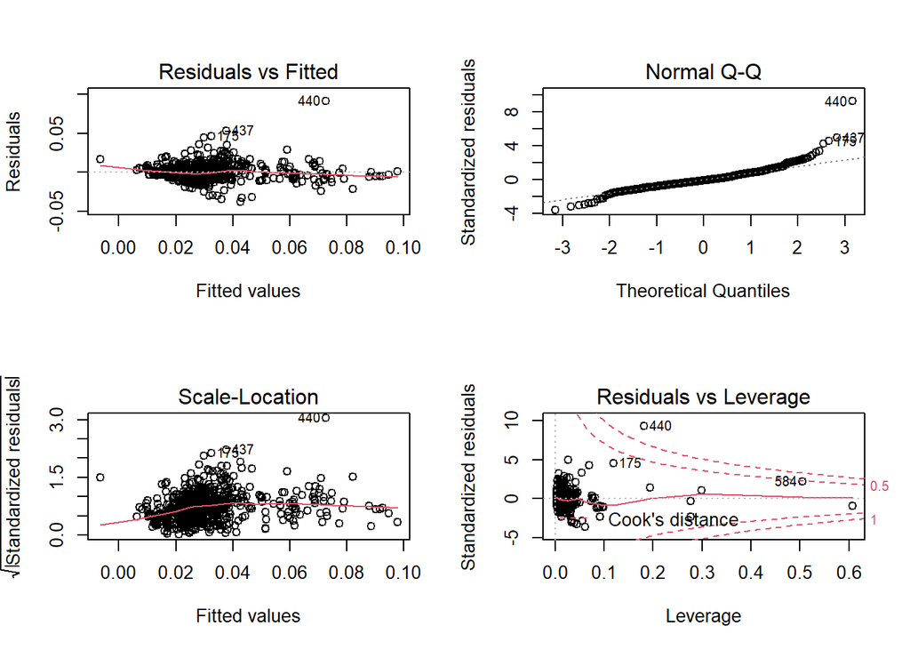

```r
par(mfrow=c(1,2))
scatter.smooth(crime$polpc,crime$crmrte,xlab='police per capita', ylab ='crimes committed per person', xlim=c(0.0005,0.0025),ylim=c(0,0.1),main = 'Police - Crime')
scatter.smooth(crime$density,crime$crmrte, xlab='hundreds of people per square mile',ylab='crimes committed per person', xlim=c(0,2.5), ylim=c(0,0.12),main='Density - Crime')
```

**plot**

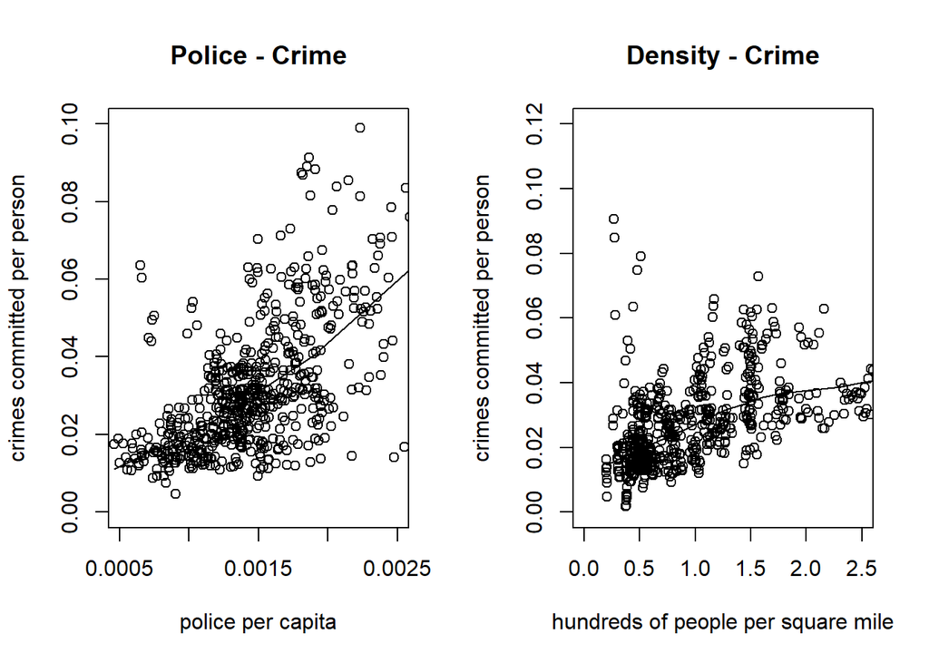

결과 시각화

### **4. 다중회귀모델 평가**

```r
summary(lm)
```

**output**

```
##
## Call:
## lm(formula = crmrte ~ polpc + density + taxpc + smsa + pctmin +
##     wfir + wser + wfed + mix + pctymle, data = crime)
##
## Residuals:
##       Min        1Q    Median        3Q       Max
## -0.037827 -0.005973 -0.001046  0.005427  0.091190
##
## Coefficients:
##               Estimate Std. Error t value Pr(>|t|)
## (Intercept) -1.053e-02  3.990e-03  -2.638 0.008549 **
## polpc        1.660e+00  1.672e-01   9.925  < 2e-16 ***
## density      9.118e-03  6.090e-04  14.972  < 2e-16 ***
## taxpc        1.540e-04  4.106e-05   3.751 0.000192 ***
## smsa        -6.829e-03  2.773e-03  -2.462 0.014082 *
## pctmin       2.610e-04  2.717e-05   9.603  < 2e-16 ***
## wfir        -3.336e-05  1.081e-05  -3.086 0.002117 **
## wser        -7.460e-06  4.324e-06  -1.725 0.084986 .
## wfed         4.179e-05  1.063e-05   3.930 9.47e-05 ***
## mix         -1.421e-02  2.147e-03  -6.615 8.02e-11 ***
## pctymle      1.280e-01  1.855e-02   6.899 1.30e-11 ***
## ---
## Signif. codes:  0 '***' 0.001 '**' 0.01 '*' 0.05 '.' 0.1 ' ' 1
##
## Residual standard error: 0.01088 on 619 degrees of freedom
## Multiple R-squared:  0.6452, Adjusted R-squared:  0.6395
## F-statistic: 112.6 on 10 and 619 DF,  p-value: < 2.2e-16
```

### **5. 결과 해석 및 Insight 도출**

```
인사이트 도출

양의 상관관계
- 인당 경찰수, 인구 밀도, 인당 세율, 미성년자 비율, 공무원 주급, 젊은 남성의 비율

음의 상관관계
- 비대면대비 대면 범죄율,  금융산업의 주급
```

### **6. 추가 분석 시행**

#### 로지스틱 회귀분석

```r
crime<-read.csv("C:\\Users\\LENOVO\\Desktop\\이민준\\3주차\\팀플-01\\R Team Project (2)\\Crime in North Carolina.csv")
#boxplot을 그려 지역별 범죄율에 차이가 있는지 우선 직관적으로 눈으로 확인
boxplot(crmrte~region, outline=FALSE, data=crime)
```

**plot**

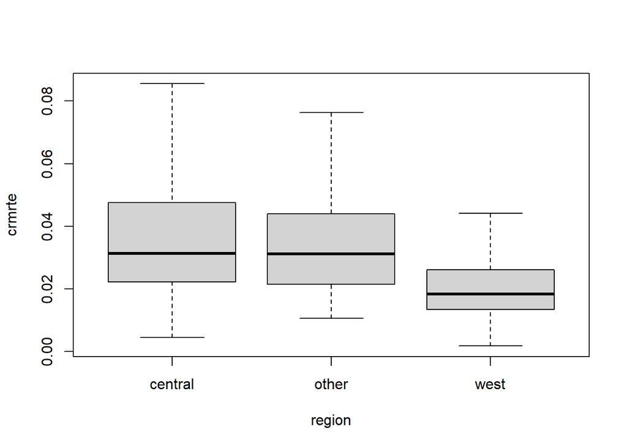

```r
#결과: 서쪽지역의 범죄율이 대체적으로 낮아보임 #이를 통계적으로 검증해보도록함 --다중로지스틱 --> 한 사람의 범죄율을 가지고 어느지역에 산다고 예측할 수 있는가?


#로지스틱 회귀분석  - 다항회귀분석(독립변수가 여러개)
str(crime) #자료의 유형 확인
```

**output**

```
## 'data.frame':    630 obs. of  25 variables:
##  $ X      : int  1 2 3 4 5 6 7 8 9 10 ...
##  $ county : int  1 1 1 1 1 1 1 3 3 3 ...
##  $ year   : int  81 82 83 84 85 86 87 81 82 83 ...
##  $ crmrte : num  0.0399 0.0383 0.0303 0.0347 0.0366 ...
##  $ prbarr : num  0.29 0.338 0.33 0.363 0.325 ...
##  $ prbconv: num  0.402 0.433 0.526 0.605 0.579 ...
##  $ prbpris: num  0.472 0.507 0.48 0.52 0.497 ...
##  $ avgsen : num  5.61 5.59 5.8 6.89 6.55 6.9 6.71 8.45 5.71 8.69 ...
##  $ polpc  : num  0.00179 0.00177 0.00184 0.00189 0.00192 ...
##  $ density: num  2.31 2.33 2.34 2.35 2.36 ...
##  $ taxpc  : num  25.7 24.9 26.5 26.8 28.1 ...
##  $ region : chr  "central" "central" "central" "central" ...
##  $ smsa   : chr  "no" "no" "no" "no" ...
##  $ pctmin : num  20.2 20.2 20.2 20.2 20.2 ...
##  $ wcon   : num  206 213 220 223 244 ...
##  $ wtuc   : num  334 369 1395 399 359 ...
##  $ wtrd   : num  182 190 197 201 207 ...
##  $ wfir   : num  272 301 310 350 383 ...
##  $ wser   : num  216 232 240 252 261 ...
##  $ wmfg   : num  229 240 270 282 299 ...
##  $ wfed   : num  409 420 439 459 490 ...
##  $ wsta   : num  236 254 250 262 281 ...
##  $ wloc   : num  231 237 249 264 289 ...
##  $ mix    : num  0.0999 0.103 0.0807 0.0785 0.0932 ...
##  $ pctymle: num  0.0877 0.0864 0.0851 0.0838 0.0823 ...
```

```r
#region을 팩터형으로 변환
crime$region <- factor(crime$region)
str(crime)
```

**output**

```
## 'data.frame':    630 obs. of  25 variables:
##  $ X      : int  1 2 3 4 5 6 7 8 9 10 ...
##  $ county : int  1 1 1 1 1 1 1 3 3 3 ...
##  $ year   : int  81 82 83 84 85 86 87 81 82 83 ...
##  $ crmrte : num  0.0399 0.0383 0.0303 0.0347 0.0366 ...
##  $ prbarr : num  0.29 0.338 0.33 0.363 0.325 ...
##  $ prbconv: num  0.402 0.433 0.526 0.605 0.579 ...
##  $ prbpris: num  0.472 0.507 0.48 0.52 0.497 ...
##  $ avgsen : num  5.61 5.59 5.8 6.89 6.55 6.9 6.71 8.45 5.71 8.69 ...
##  $ polpc  : num  0.00179 0.00177 0.00184 0.00189 0.00192 ...
##  $ density: num  2.31 2.33 2.34 2.35 2.36 ...
##  $ taxpc  : num  25.7 24.9 26.5 26.8 28.1 ...
##  $ region : Factor w/ 3 levels "central","other",..: 1 1 1 1 1 1 1 1 1 1 ...
##  $ smsa   : chr  "no" "no" "no" "no" ...
##  $ pctmin : num  20.2 20.2 20.2 20.2 20.2 ...
##  $ wcon   : num  206 213 220 223 244 ...
##  $ wtuc   : num  334 369 1395 399 359 ...
##  $ wtrd   : num  182 190 197 201 207 ...
##  $ wfir   : num  272 301 310 350 383 ...
##  $ wser   : num  216 232 240 252 261 ...
##  $ wmfg   : num  229 240 270 282 299 ...
##  $ wfed   : num  409 420 439 459 490 ...
##  $ wsta   : num  236 254 250 262 281 ...
##  $ wloc   : num  231 237 249 264 289 ...
##  $ mix    : num  0.0999 0.103 0.0807 0.0785 0.0932 ...
##  $ pctymle: num  0.0877 0.0864 0.0851 0.0838 0.0823 ...
```

```r
#지역 세 개에 대한 회귀모델을 돌림
library(nnet)
(m <- multinom(region ~. , data=crime))
```

**output**

**output**

```
## Call:
## multinom(formula = region ~ ., data = crime)
##
## Coefficients:
##       (Intercept)             X        county      year   crmrte    prbarr
## other   -37.91687 -0.0002638348  0.0007885486 0.5271542 54.20816 0.1132631
## west    -28.53952  0.1431552120 -0.4437584310 0.5045986 36.87921 2.3620175
##           prbconv   prbpris      avgsen    polpc    density       taxpc
## other -0.34445169 -0.993569  0.03741133 -6.27140 -0.7965438  0.05394657
## west   0.03460743 -1.990416 -0.10104816 22.51134 -4.7057890 -0.11554028
##         smsayes      pctmin         wcon         wtuc        wtrd         wfir
## other  1.663168  0.09430587 -0.004933503 0.0003537535 -0.01920300  0.006204342
## west  12.433872 -0.28273007 -0.001332611 0.0012055870 -0.05118424 -0.006455757
##               wser         wmfg         wfed         wsta        wloc
## other -0.002460529 -0.004176241 -0.005096605 -0.005159815 -0.01450612
## west   0.004394109  0.004127761  0.020745512 -0.004609012 -0.01149170
##              mix  pctymle
## other -6.8335972 17.18286
## west   0.9601067 20.38396
##
## Residual Deviance: 534.1925
## AIC: 634.1925
```

```r
#fitted() :각 행의 데이터가 각 분류에 속할 확률
head(fitted(m))
```

**output**

```
##     central     other         west
## 1 0.8821819 0.1177334 8.470114e-05
## 2 0.8812034 0.1186857 1.109661e-04
## 3 0.8639339 0.1356553 4.107994e-04
## 4 0.8539410 0.1458709 1.880537e-04
## 5 0.8732815 0.1264760 2.424934e-04
## 6 0.8677132 0.1321766 1.101447e-04
```

```r
#어떤 지역일지를 예측 (class별)
predict(m, newdata = crime [c(1,51,101),],type = "class")
```

**output**

```
## [1] central other   other
## Levels: central other west
```

```r
#어떤 지역일지를 예측 (확률로 )
predict(m, newdata = crime [c(1,51,101),],type = "probs")
```

**output**

```
##        central     other         west
## 1   0.88218186 0.1177334 8.470114e-05
## 51  0.08871626 0.9112828 9.479126e-07
## 101 0.11574714 0.8842400 1.281690e-05
```

```r
#모델 정확도
predicted <- predict(m, newdata=crime)
sum(predicted == crime$region) / NROW(predicted)
```

**output**

```
## [1] 0.8079365
```

```r
#테이블형식으로정리
xtabs(~predicted + crime$region )
```

**output**

```
##          crime$region
## predicted central other west
##   central     168    35   10
##   other        50   209    5
##   west         20     1  132
```

#### 다른 변수들 간의 상관관계 파악

```r
#QQ-plot으로 변수 prbpris가 정규를 따르는지 확인
crime<-read.csv("C:\\Users\\LENOVO\\Desktop\\이민준\\3주차\\팀플-01\\R Team Project (2)\\Crime in North Carolina.csv")

qqnorm(crime$prbpris)
qqline(crime$prbpris, lwd=2)
```

**plot**

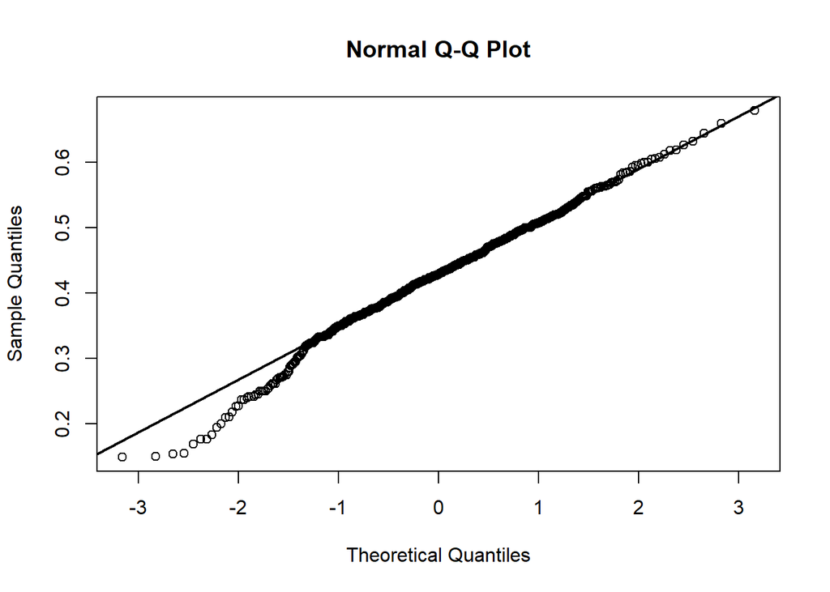

```r
#박스플롯으로 이상치 보고 제거
boxplot(crime$ prbpris)$stats
```

**plot**

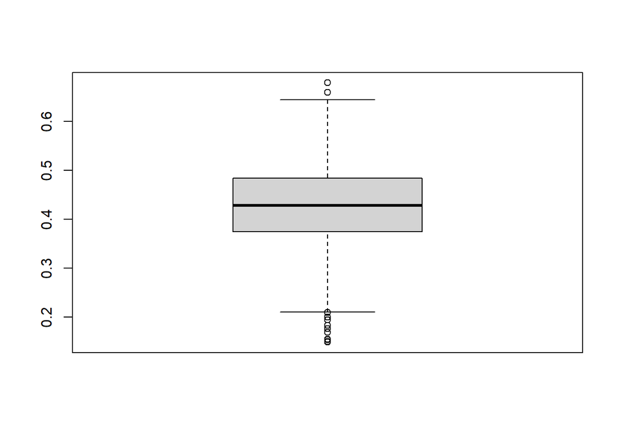

**output**

```
##          [,1]
## [1,] 0.210526
## [2,] 0.374204
## [3,] 0.428571
## [4,] 0.483333
## [5,] 0.644493
```

```r
library(dplyr)
new_data <- crime %>% select(prbpris) %>% filter(  0.210526 <= prbpris & 0.644493 >= prbpris)

#0.05이상으로 정규성을 따름
shapiro.test(new_data$prbpris)
```

**output**

```
##
##  Shapiro-Wilk normality test
##
## data:  new_data$prbpris
## W = 0.99516, p-value = 0.05021
```

```r
#이를 QQ-plot과 density로 다시 확인
qqnorm(new_data$prbpris)
qqline(new_data$prbpris, lwd=2)

library(ggpubr)
```

**plot**

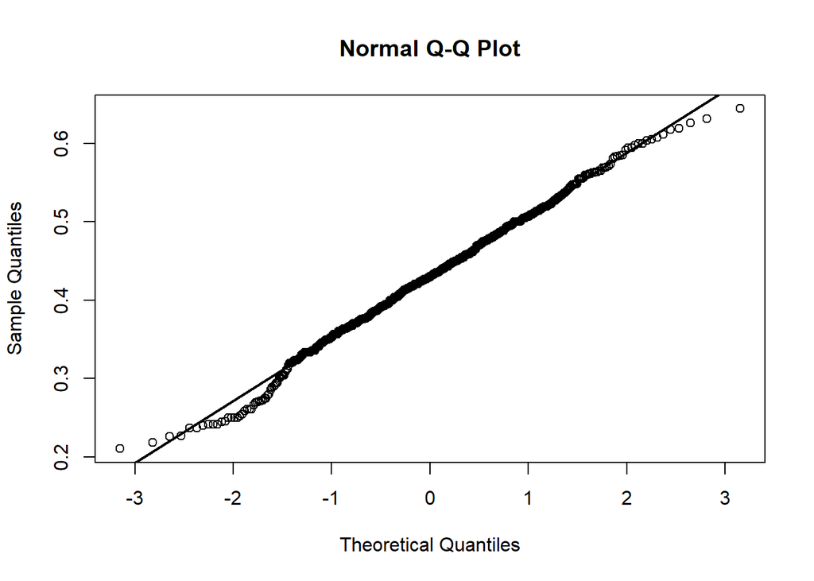

```r
ggdensity(new_data$prbpris)
```

**plot**

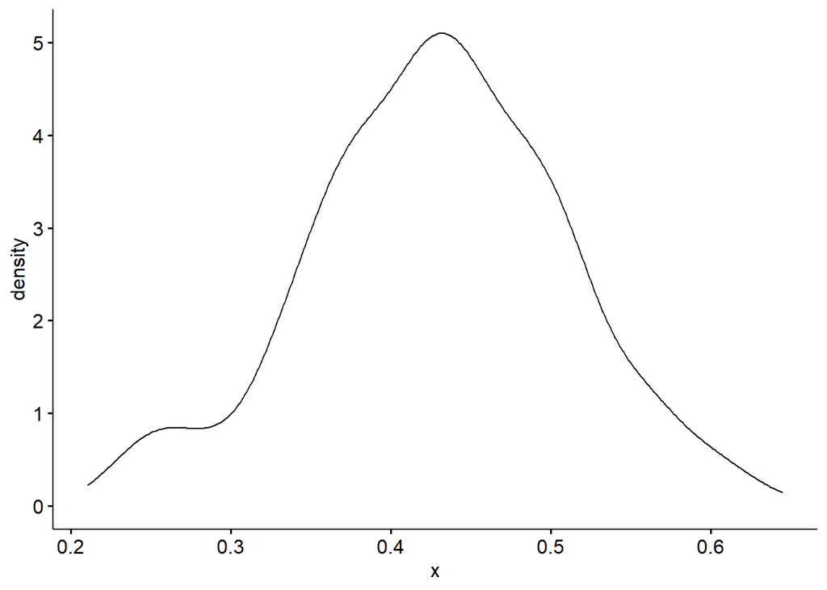